# Assignment 6 Nextech Case

Author

Sebastian Perez Parra

Published

September 25, 2025

We start by loading the necessary libraries and the dataset.

```r
#load libraries
library(tidyverse)
library(rpact)
library(MatchIt)
library(marginaleffects)
```

```r
#load historical data
d <- read_csv("https://raw.githubusercontent.com/jefftwebb/data/main/management_training.csv")
```

# 1

We begin by estimating the average treatment effect (ATE) by calculating the difference in mean engagement scores for treatment vs. control.

```r
mean(filter(d, intervention == 1)$engagement_score) - mean(filter(d, intervention == 0)$engagement_score)
```

```
[1] 0.4346287
```

or using regression. Either way will give us the same result.

```r
summary(lm(engagement_score ~ intervention, data  = d))
```

```
Call:
lm(formula = engagement_score ~ intervention, data = d)

Residuals:
    Min      1Q  Median      3Q     Max
-2.9799 -0.6799 -0.0299  0.6548  3.3601

Coefficients:
             Estimate Std. Error t value Pr(>|t|)
(Intercept)  -0.23476    0.01412  -16.62   <2e-16 ***
intervention  0.43463    0.01922   22.62   <2e-16 ***
---
Signif. codes:  0 '***' 0.001 '**' 0.01 '*' 0.05 '.' 0.1 ' ' 1

Residual standard error: 0.9764 on 10389 degrees of freedom
Multiple R-squared:  0.04692,   Adjusted R-squared:  0.04683
F-statistic: 511.5 on 1 and 10389 DF,  p-value: < 2.2e-16
```

# 2

Now we Estimate ATE with multiple regression, adjusting for possible confounders. We include all the variables except for `department_id` which is just an identifier.

```r
summary(lm(engagement_score ~ intervention + tenure + n_of_reports + gender + role + last_engagement_score + department_score + department_size, data = d))
```

```
Call:
lm(formula = engagement_score ~ intervention + tenure + n_of_reports +
    gender + role + last_engagement_score + department_score +
    department_size, data = d)

Residuals:
    Min      1Q  Median      3Q     Max
-2.4189 -0.6117 -0.0133  0.5776  3.2175

Coefficients:
                        Estimate Std. Error t value Pr(>|t|)
(Intercept)           -1.734e+00  5.620e-02 -30.855  < 2e-16 ***
intervention           2.713e-01  1.769e-02  15.336  < 2e-16 ***
tenure                 3.651e-01  7.836e-03  46.589  < 2e-16 ***
n_of_reports          -1.573e-03  3.914e-03  -0.402  0.68783
gender                -2.755e-01  1.720e-02 -16.013  < 2e-16 ***
role                   5.149e-02  6.885e-03   7.479  8.1e-14 ***
last_engagement_score -6.051e-03  6.796e-03  -0.890  0.37327
department_score       7.234e-04  9.865e-03   0.073  0.94154
department_size       -4.905e-05  1.773e-05  -2.767  0.00567 **
---
Signif. codes:  0 '***' 0.001 '**' 0.01 '*' 0.05 '.' 0.1 ' ' 1

Residual standard error: 0.8755 on 10382 degrees of freedom
Multiple R-squared:  0.2341,    Adjusted R-squared:  0.2335
F-statistic: 396.7 on 8 and 10382 DF,  p-value: < 2.2e-16
```

- The naive effect of the treatment show a great positive effect of the management training where the treatment showed an improvement of 0.43 in the engagement score. The effect with the regression is statistically significant but shows a decrease in the effect, estimating only 0.27 increase in engagement scores. This suggests that the naive effect is biased upward increasing the treatment effect.
- The large naive effect is very possibly biased with selection. Since the data is historical observed data that is non compliant because some managers assigned to the training did not attend, while others attended without having been assigned, self selection was introduced. This eliminates any randomization. This difference could also be a hint of potential confounders, pre existing differences in the data that affect the treatment and the outcome.

# 3

We use coarsened exact matching (CEM) to create synthetic treatment and control groups for estimating the treatment effect and estimate the treatment effect (ATM) using the matched sample.

**First**, we do the matching. Intervention is the dependent variable in the formula and outcome is left out because we are *modeling treatment assignment*. This creates a matchit object.

```r
m_cem <- matchit(formula = intervention ~ department_id + tenure + n_of_reports + gender + role + last_engagement_score + department_score + department_size,
                 data = d,
                 cutpoints = "sturges",
                 # you could try = "sturges" for automatic bin selection
                 method = "cem")

m_cem
```

```
A `matchit` object
 - method: Coarsened exact matching
 - number of obs.: 10391 (original), 4982 (matched)
 - target estimand: ATT
 - covariates: department_id, tenure, n_of_reports, gender, role, last_engagement_score, department_score, department_size
```

**Second**, we check the matches.

```r
summary(m_cem)
```

```
Call:
matchit(formula = intervention ~ department_id + tenure + n_of_reports +
    gender + role + last_engagement_score + department_score +
    department_size, data = d, method = "cem", cutpoints = "sturges")

Summary of Balance for All Data:
                      Means Treated Means Control Std. Mean Diff. Var. Ratio
department_id               39.9390       39.8299          0.0045     1.0135
tenure                       5.4742        5.0262          0.4289     0.8138
n_of_reports                 4.3039        4.3017          0.0010     0.8967
gender                       1.4755        1.5069         -0.0629     0.9978
role                         2.4140        2.4874         -0.0544     0.9171
last_engagement_score        0.1895       -0.0977          0.2092     1.0164
department_score            -0.0932        0.0387         -0.1364     0.9227
department_size            928.7747      862.1856          0.1264     1.0389
                      eCDF Mean eCDF Max
department_id            0.0096   0.0258
tenure                   0.0640   0.1834
n_of_reports             0.0186   0.0341
gender                   0.0157   0.0314
role                     0.0259   0.0649
last_engagement_score    0.0367   0.0967
department_score         0.0260   0.0786
department_size          0.0346   0.0780

Summary of Balance for Matched Data:
                      Means Treated Means Control Std. Mean Diff. Var. Ratio
department_id               42.2135       42.2085          0.0002     0.9997
tenure                       5.4940        5.4940         -0.0000     0.9996
n_of_reports                 4.2120        4.2120          0.0000     0.9996
gender                       1.4989        1.4989          0.0000     0.9996
role                         2.4605        2.4605          0.0000     0.9996
last_engagement_score        0.2392        0.2426         -0.0024     0.9939
department_score            -0.1515       -0.1515          0.0000     0.9996
department_size           1048.0357     1047.9729          0.0001     0.9993
                      eCDF Mean eCDF Max Std. Pair Dist.
department_id            0.0002   0.0021          0.0008
tenure                   0.0000   0.0000          0.0000
n_of_reports             0.0000   0.0000          0.0000
gender                   0.0000   0.0000          0.0000
role                     0.0000   0.0000          0.0000
last_engagement_score    0.0023   0.0118          0.1636
department_score         0.0000   0.0000          0.0000
department_size          0.0002   0.0021          0.0002

Sample Sizes:
              Control Treated
All           4780.      5611
Matched (ESS) 1315.78    2660
Matched       2322.      2660
Unmatched     2458.      2951
Discarded        0.         0
```

**Third**, we plot the matches to evaluate improvement. The goal is minimize treatment/control differences in the matched sample.

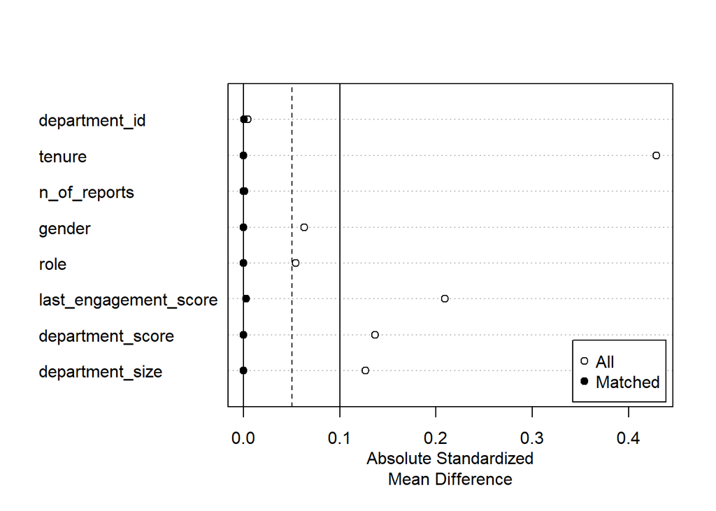

```r
plot(summary(m_cem))
```

In general this is an improvement: the matched sample variables are moving towards 0.

**Fourth**, we construct the matched data set. This consists in a subset of only the matched units.

```r
(matched_cem <- match.data(m_cem))
```

```
# A tibble: 4,982 × 12
   department_id intervention engagement_score tenure n_of_reports gender  role
           <dbl>        <dbl>            <dbl>  <dbl>        <dbl>  <dbl> <dbl>
 1            76            1             0.28      6            4      2     4
 2            76            1             0.77      6            4      2     4
 3            76            1            -0.12      6            4      2     4
 4            76            1             1.53      6            4      1     4
 5            76            1             0.01      6            4      2     4
 6            76            1             1.74      6            4      1     4
 7            76            1             1.26      6            4      1     4
 8            76            1            -2.05      4            4      2     4
 9            76            1            -0.24      6            4      1     4
10            76            1             0.54      6            4      1     4
# ℹ 4,972 more rows
# ℹ 5 more variables: last_engagement_score <dbl>, department_score <dbl>,
#   department_size <dbl>, weights <dbl>, subclass <fct>
```

**Finally**, we do the analysis using the matched data.

```r
lm(engagement_score ~ intervention + department_id + tenure + n_of_reports + gender + role + last_engagement_score + department_score + department_size,
   weights = weights, # this is necessary because of number differences in subclass
   data = matched_cem) |>
  summary()
```

```
Call:
lm(formula = engagement_score ~ intervention + department_id +
    tenure + n_of_reports + gender + role + last_engagement_score +
    department_score + department_size, data = matched_cem, weights = weights)

Weighted Residuals:
    Min      1Q  Median      3Q     Max
-4.0440 -0.5425  0.0029  0.5181  4.7279

Coefficients:
                        Estimate Std. Error t value Pr(>|t|)
(Intercept)           -2.105e+00  1.087e-01 -19.378  < 2e-16 ***
intervention           2.192e-01  2.407e-02   9.107  < 2e-16 ***
department_id         -5.473e-03  5.270e-04 -10.385  < 2e-16 ***
tenure                 4.533e-01  1.642e-02  27.607  < 2e-16 ***
n_of_reports          -3.812e-03  6.444e-03  -0.592    0.554
gender                -2.715e-01  2.406e-02 -11.285  < 2e-16 ***
role                   6.054e-02  1.016e-02   5.959 2.71e-09 ***
last_engagement_score  9.980e-04  1.091e-02   0.091    0.927
department_score       2.010e-02  1.525e-02   1.319    0.187
department_size        2.046e-05  2.452e-05   0.834    0.404
---
Signif. codes:  0 '***' 0.001 '**' 0.01 '*' 0.05 '.' 0.1 ' ' 1

Residual standard error: 0.8474 on 4972 degrees of freedom
Multiple R-squared:  0.1854,    Adjusted R-squared:  0.184
F-statistic: 125.8 on 9 and 4972 DF,  p-value: < 2.2e-16
```

- The estimated treatment effect (ATM) using the matched sample is 0.22. That is, 0.22 more for the engagement score in the treatment than the control.

# 4

Calculate and summarize propensity scores for the training program.

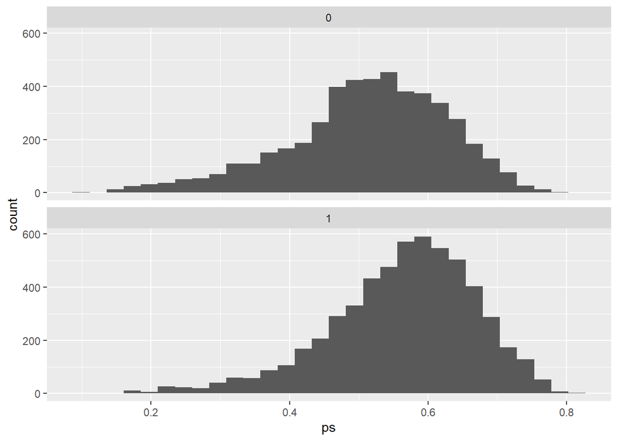

```r
# 1. Estimate propensity scores
ps_model <- glm(intervention ~ department_id + tenure + n_of_reports + gender + role + last_engagement_score + department_score + department_size,
                family = "binomial",
                data = d)

# 2. Predict probabilities.  Use type = "response".
d$ps <- predict(ps_model, type = "response")

# 3. Calculate IPW
d <- d |>
  mutate(ipw = ifelse(intervention == 1, 1/ps, 1/(1 - ps)))

# 4. Check overlap of propensity scores for trimming
ggplot(d, aes(ps)) +
  geom_histogram() +
  facet_wrap(~intervention, ncol = 1)
```

```r
# or

summary(filter(d, intervention == 1)$ps)
```

```
   Min. 1st Qu.  Median    Mean 3rd Qu.    Max.
 0.1068  0.5038  0.5764  0.5636  0.6370  0.8172
```

```r
summary(filter(d, intervention == 0)$ps)
```

```
   Min. 1st Qu.  Median    Mean 3rd Qu.    Max.
 0.1010  0.4511  0.5234  0.5123  0.5939  0.7878
```

- The best cut offs for trimming the data to ensure overlap in propensity scores between treatment and control prior to doing an analysis with inverse propensity score weighting (IPW) are 0.1 and 0.78

# 5

We use IPW in regression to estimate the ATE of the training program.

```r
lm(engagement_score ~ intervention + department_id + tenure + n_of_reports + gender + role + last_engagement_score + department_score + department_size,
   weights = ipw,
   data = filter(d, ps > .1 & ps < .78)) |>
  summary()
```

```
Call:
lm(formula = engagement_score ~ intervention + department_id +
    tenure + n_of_reports + gender + role + last_engagement_score +
    department_score + department_size, data = filter(d, ps >
    0.1 & ps < 0.78), weights = ipw)

Weighted Residuals:
    Min      1Q  Median      3Q     Max
-3.6020 -0.8474 -0.0138  0.8021  6.4145

Coefficients:
                        Estimate Std. Error t value Pr(>|t|)
(Intercept)           -1.597e+00  5.648e-02 -28.284   <2e-16 ***
intervention           2.722e-01  1.709e-02  15.929   <2e-16 ***
department_id         -4.107e-03  3.734e-04 -10.998   <2e-16 ***
tenure                 3.556e-01  7.512e-03  47.346   <2e-16 ***
n_of_reports           2.230e-03  3.893e-03   0.573    0.567
gender                -2.769e-01  1.711e-02 -16.185   <2e-16 ***
role                   5.775e-02  6.833e-03   8.451   <2e-16 ***
last_engagement_score -9.300e-03  6.752e-03  -1.378    0.168
department_score       1.370e-02  9.806e-03   1.398    0.162
department_size        5.698e-06  1.811e-05   0.315    0.753
---
Signif. codes:  0 '***' 0.001 '**' 0.01 '*' 0.05 '.' 0.1 ' ' 1

Residual standard error: 1.231 on 10370 degrees of freedom
Multiple R-squared:  0.2218,    Adjusted R-squared:  0.2211
F-statistic: 328.4 on 9 and 10370 DF,  p-value: < 2.2e-16
```

=The estimated ATE using IPW in regressions for intervention is 0.27.

Now we perform bootstrap analysis for robust results.

```r
# initialize the vector of simulated estimates
boot_dist <- NA

for(i in 1:200){

  # initialize the bootstrap sample
  boot_samp <- slice_sample(.data = d, prop = 1, replace = T) # check ?slice_sample

  # Estimate propensity scores
  ps_model <- glm(intervention ~ department_id + tenure + n_of_reports + gender + role + last_engagement_score + department_score + department_size,
                family = "binomial",
                data = boot_samp) # use the bootstrap sample here

  # Predict probabilities.  Use type = "response".
  boot_samp$ps <- predict(ps_model, type = "response")

  # Calculate IPW
  boot_samp <- boot_samp |>
    mutate(ipw = ifelse(intervention == 1, 1/ps, 1/(1 - ps)))

  # Estimate effects using ipw as weights but trim out the lowest and highest ps
  fit <- lm(engagement_score ~ intervention + department_id + tenure + n_of_reports + gender + role + last_engagement_score + department_score + department_size,
            weights = ipw,
            data = filter(boot_samp, ps > .05 & ps < .95))  # make a guess about trimming

  # Store estimated ATE
  boot_dist[i] <- avg_comparisons(fit,
                                variables = "intervention",
                                wts = "ipw")$estimate

   print(i) # make sure to comment this out before compiling!
}
```

[output not shown]

[output cut: 185 more lines]

```r
# non-parametric bootstrap estimate:
quantile(boot_dist, probs = c(.025, .5, .975), na.rm = TRUE)
```

```
     2.5%       50%     97.5%
0.2408826 0.2692325 0.3004165
```

```r
# There is also a parametric bootstrap that uses SD as SE
se <- sd(boot_dist)
mean(boot_dist) - 1.96 * se # lower bound
```

```
[1] 0.2377121
```

```r
mean(boot_dist) + 1.96 * se # upper bound
```

```
[1] 0.3020273
```

# 6

We use full matching to create weighted synthetic treatment and control groups and we estimate ATE using G-Computation in the `marginaleffects` package.

```r
# 1. Create the matchit object with glm as the (default) method for estimating propensity scores
m_full <- matchit(formula = intervention ~ department_id + tenure + n_of_reports + gender + role + last_engagement_score + department_score + department_size,
                 data = d,
                 method = "full") # method = "quick" is an optimized version of "full"

# 2. Evaluate balance
summary(m_full)
```

```
Call:
matchit(formula = intervention ~ department_id + tenure + n_of_reports +
    gender + role + last_engagement_score + department_score +
    department_size, data = d, method = "full")

Summary of Balance for All Data:
                      Means Treated Means Control Std. Mean Diff. Var. Ratio
distance                     0.5636        0.5123          0.4888     0.8285
department_id               39.9390       39.8299          0.0045     1.0135
tenure                       5.4742        5.0262          0.4289     0.8138
n_of_reports                 4.3039        4.3017          0.0010     0.8967
gender                       1.4755        1.5069         -0.0629     0.9978
role                         2.4140        2.4874         -0.0544     0.9171
last_engagement_score        0.1895       -0.0977          0.2092     1.0164
department_score            -0.0932        0.0387         -0.1364     0.9227
department_size            928.7747      862.1856          0.1264     1.0389
                      eCDF Mean eCDF Max
distance                 0.1323   0.2095
department_id            0.0096   0.0258
tenure                   0.0640   0.1834
n_of_reports             0.0186   0.0341
gender                   0.0157   0.0314
role                     0.0259   0.0649
last_engagement_score    0.0367   0.0967
department_score         0.0260   0.0786
department_size          0.0346   0.0780

Summary of Balance for Matched Data:
                      Means Treated Means Control Std. Mean Diff. Var. Ratio
distance                     0.5636        0.5635          0.0002     1.0001
department_id               39.9390       47.3273         -0.3068     0.8893
tenure                       5.4742        5.4719          0.0022     1.0862
n_of_reports                 4.3039        4.3646         -0.0283     0.9644
gender                       1.4755        1.4608          0.0294     1.0032
role                         2.4140        2.5586         -0.1071     0.9352
last_engagement_score        0.1895        0.2338         -0.0322     1.0149
department_score            -0.0932       -0.0954          0.0022     1.1502
department_size            928.7747      949.8373         -0.0400     1.1132
                      eCDF Mean eCDF Max Std. Pair Dist.
distance                 0.0006   0.0036          0.0032
department_id            0.0972   0.1835          1.0736
tenure                   0.0041   0.0146          0.4440
n_of_reports             0.0076   0.0172          1.0817
gender                   0.0073   0.0147          0.9714
role                     0.0313   0.0834          1.1146
last_engagement_score    0.0070   0.0251          0.9864
department_score         0.0185   0.0545          1.0063
department_size          0.0269   0.0667          0.9986

Sample Sizes:
              Control Treated
All           4780.      5611
Matched (ESS) 1322.43    5611
Matched       4780.      5611
Unmatched        0.         0
Discarded        0.         0
```

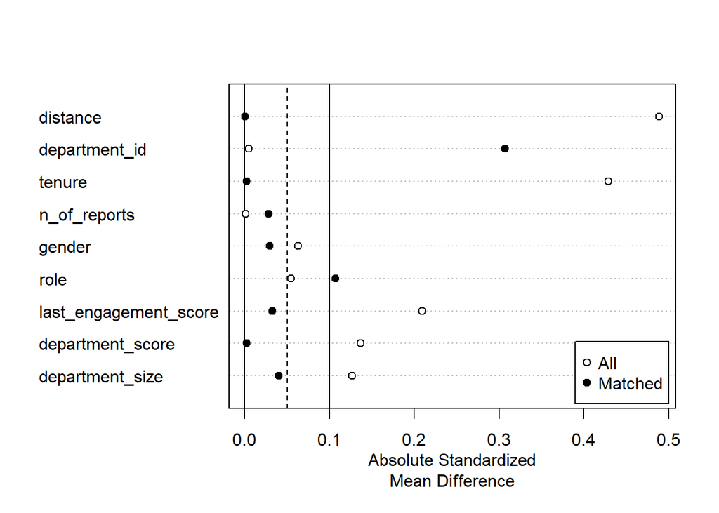

```r
plot(summary(m_full))
```

```r
# 3. Create the matched data
(matched_full <- match.data(m_full))
```

```
# A tibble: 10,391 × 15
   department_id intervention engagement_score tenure n_of_reports gender  role
           <dbl>        <dbl>            <dbl>  <dbl>        <dbl>  <dbl> <dbl>
 1            76            1             0.28      6            4      2     4
 2            76            1            -0.45      4            8      2     4
 3            76            1             0.77      6            4      2     4
 4            76            1            -0.12      6            4      2     4
 5            76            1             1.53      6            4      1     4
 6            76            1             0.01      6            4      2     4
 7            76            1             1.74      6            4      1     4
 8            76            1             0.95      6            4      1     4
 9            76            1             2.37      6            5      2     4
10            76            1             1.26      6            4      1     4
# ℹ 10,381 more rows
# ℹ 8 more variables: last_engagement_score <dbl>, department_score <dbl>,
#   department_size <dbl>, ps <dbl>, ipw <dbl>, distance <dbl>, weights <dbl>,
#   subclass <fct>
```

```r
# 4. Do the analysis using the weights that have been added to the matched data
model <- lm(engagement_score ~ intervention + department_id + tenure + n_of_reports + gender + role + last_engagement_score + department_score + department_size,
   data = matched_full,
   weights = weights)
  summary(model)
```

```
Call:
lm(formula = engagement_score ~ intervention + department_id +
    tenure + n_of_reports + gender + role + last_engagement_score +
    department_score + department_size, data = matched_full,
    weights = weights)

Weighted Residuals:
    Min      1Q  Median      3Q     Max
-6.7238 -0.5429 -0.0051  0.5208  5.8310

Coefficients:
                        Estimate Std. Error t value Pr(>|t|)
(Intercept)           -1.921e+00  6.126e-02 -31.352   <2e-16 ***
intervention           2.569e-01  1.728e-02  14.869   <2e-16 ***
department_id         -4.349e-03  3.639e-04 -11.951   <2e-16 ***
tenure                 4.190e-01  8.375e-03  50.026   <2e-16 ***
n_of_reports          -3.306e-03  3.956e-03  -0.836    0.403
gender                -2.728e-01  1.708e-02 -15.973   <2e-16 ***
role                   7.315e-02  6.858e-03  10.666   <2e-16 ***
last_engagement_score  5.572e-03  6.702e-03   0.831    0.406
department_score       5.054e-03  1.019e-02   0.496    0.620
department_size       -1.790e-05  1.823e-05  -0.982    0.326
---
Signif. codes:  0 '***' 0.001 '**' 0.01 '*' 0.05 '.' 0.1 ' ' 1

Residual standard error: 0.8672 on 10381 degrees of freedom
Multiple R-squared:  0.238, Adjusted R-squared:  0.2373
F-statistic: 360.2 on 9 and 10381 DF,  p-value: < 2.2e-16
```

Use marginal effects package to back out the treatment effect from this complicated model.

```r
avg_comparisons(model,
                variables = "intervention", #  identify the treatment variable
                wts = "ipw")$estimate # extract the estimate
```

```
[1] 0.2569447
```

Using bootstrapping

```r
# initialize the vector of simulated estimates
boot_dist <- NA

for(i in 1:200){

  # initialize the bootstrap sample
  boot_samp <- slice_sample(.data = d, prop = 1, replace = T) # check ?slice_sample

  # Estimate propensity scores
  ps_model <- glm(intervention ~ department_id + tenure + n_of_reports + gender + role + last_engagement_score + department_score + department_size,
                family = "binomial",
                data = boot_samp) # use the bootstrap sample here

  # Predict probabilities.  Use type = "response".
  boot_samp$ps <- predict(ps_model, type = "response")

  # Calculate IPW
  boot_samp <- boot_samp |>
    mutate(ipw = ifelse(intervention == 1, 1/ps, 1/(1 - ps)))

  # Estimate effects using ipw as weights but trim out the lowest and highest ps
  fit <- lm(engagement_score ~ intervention + department_id + tenure + n_of_reports + gender + role + last_engagement_score + department_score + department_size,
            weights = ipw,
            data = filter(boot_samp, ps > .05 & ps < .95))  # make a guess about trimming

  # Store estimated ATE
  boot_dist[i] <- avg_comparisons(fit,
                                variables = "intervention",
                                wts = "ipw")$estimate

   print(i) # make sure to comment this out before compiling!
}
```

[output not shown]

[output cut: 185 more lines]

```r
# non-parametric bootstrap estimate:
quantile(boot_dist, probs = c(.025, .5, .975), na.rm = TRUE)
```

```
     2.5%       50%     97.5%
0.2333146 0.2737380 0.3064985
```

```r
# There is also a parametric bootstrap that uses SD as SE
se <- sd(boot_dist)
mean(boot_dist) - 1.96 * se # lower bound
```

```
[1] 0.2325838
```

```r
mean(boot_dist) + 1.96 * se # upper bound
```

```
[1] 0.3101654
```

# 7

Nextech launched a managerial training program to improve team engagement, but participation was non compliant raising concerns about confounding. Managers who opted into training may differ systematically from those who didn’t, in ways that also affect engagement outcomes. Key confounders include tenure, prior engagement scores, team size, department-level climate, and demographic factors like role and gender. These variables most probably influence both the treatment and the engagement scores we aim to measure.